# Strings and Factors

## Agenda

- Strings
- Regular expressions
- Factors
- Readings: R4DS Chapters 14-15
- Other sources:
  - [RegEx cheatsheat](https://rstudio.com/wp-content/uploads/2016/09/RegExCheatsheet.pdf)

## String basics

```r
library(tidyverse)
string1 <- "This is a string"
string2 <- 'If I want to include a "quote" inside a string, I use single quotes'
```

## String basics

```r
double_quote <- "\"" # or '"'
single_quote <- '\'' # or "'"
```

## String basics

```r
x <- c("\"", "\\")
x
## [1] "\"" "\\"
```

```
#> [1] "\"" "\\"
```

```r
writeLines(x)
## "
## \
```

Other characters: try `?'"'`

## String operations

String processing tasks can be divided into:

- detecting,
- locating,
- extracting, or
- replacing

## `stringr` functions

| stringr | Task | Description | R-base |
| --- | --- | --- | --- |
| `str_detect` | Detect | Is the pattern in the string? | `grepl` |
| `str_which` | Detect | Returns the index of entries that contain the pattern. | `grep` |
| `str_subset` | Detect | Returns the subset of strings that contain the pattern. | `grep` with `value = TRUE` |
| `str_locate` | Locate | Returns positions of first occurrence of pattern in a string. | `regexpr` |
| `str_locate_all` | Locate | Returns position of all occurrences of pattern in a string. | `gregexpr` |
| `str_view` | Locate | Show the first part of the string that matches pattern. |  |

## `stringr` functions

| stringr | Task | Description | R-base |
| --- | --- | --- | --- |
| `str_view_all` | Locate | Show me all the parts of the string that match the pattern. |  |
| `str_extract` | Extract | Extract the first part of the string that matches the pattern. |  |
| `str_extract_all` | Extract | Extract all parts of the string that match the pattern. |  |
| `str_match` | Extract | Extract first part of the string that matches the groups and the patterns defined by the groups. |  |
| `str_match_all` | Extract | Extract all parts of the string that matches the groups and the patterns defined by the groups. |  |
| `str_sub` | Extract | Extract a substring. | `substring` |

## `stringr` functions

| stringr | Task | Description | R-base |
| --- | --- | --- | --- |
| `str_split` | Extract | Split a string into a list with parts separated by pattern. | `strsplit` |
| `str_split_fixed` | Extract | Split a string into a matrix with parts separated by pattern. | `strsplit` with `fixed = TRUE` |
| `str_count` | Describe | Count number of times a pattern appears in a string. |  |
| `str_length` | Describe | Number of character in string. | `nchar` |
| `str_replace` | Replace | Replace first part of a string matching a pattern with another. |  |

## `stringr` functions

| stringr | Task | Description | R-base |
| --- | --- | --- | --- |
| `str_replace_all` | Replace | Replace all parts of a string matching a pattern with another. | `gsub` |
| `str_to_upper` | Replace | Change all characters to upper case. | `toupper` |
| `str_to_lower` | Replace | Change all characters to lower case. | `tolower` |
| `str_to_title` | Replace | Change first character to upper and rest to lower. |  |
| `str_replace_na` | Replace | Replace all `NA`s to a new value. |  |
| `str_trim` | Replace | Remove white space from start and end of string. |  |

## `stringr` functions

| stringr | Task | Description | R-base |
| --- | --- | --- | --- |
| `str_c` | Manipulate | Join multiple strings. | `paste0` |
| `str_conv` | Manipulate | Change the encoding of the string. |  |
| `str_sort` | Manipulate | Sort the vector in alphabetical order. | `sort` |
| `str_order` | Manipulate | Index needed to order the vector in alphabetical order. | `order` |
| `str_trunc` | Manipulate | Truncate a string to a fixed size. |  |
| `str_pad` | Manipulate | Add white space to string to make it a fixed size. |  |

## `stringr` functions

| stringr | Task | Description | R-base |
| --- | --- | --- | --- |
| `str_dup` | Manipulate | Repeat a string. | `rep` then `paste` |
| `str_wrap` | Manipulate | Wrap things into formatted paragraphs. |  |
| `str_interp` | Manipulate | String interpolation. | `sprintf` |

## String length

```r
str_length(c("a", "Survey of Modern Statistical Software", 9))
## [1]  1 37  1
```

## String concatenation

```r
str_c("x", "y")
## [1] "xy"
str_c("x", "y", "z")
## [1] "xyz"
str_c("x", "y", sep = ", ")
## [1] "x, y"
```

## String concatenation

```r
x <- c("abc", NA)
str_c("|-", x, "-|")
## [1] "|-abc-|" NA
str_c("|-", str_replace_na(x), "-|")
## [1] "|-abc-|" "|-NA-|"
```

## String subsetting

```r
x <- c("Apple", "Banana", "Pear")
str_sub(x, 1, 3)
## [1] "App" "Ban" "Pea"
str_sub(x, -3, -1)
## [1] "ple" "ana" "ear"
```

## Raw murders

```r
library(rvest)
url <- paste0("https://en.wikipedia.org/w/index.php?title=",
              "Gun_violence_in_the_United_States_by_state",
              "&direction=prev&oldid=810166167")
murders_raw <- read_html(url) %>%
  html_node("table") %>%
  html_table() %>%
  setNames(c("state", "population", "total", "murder_rate"))
```

## Raw murders

Converting to numeric from text (even nicely formatted text) is trickier.

```r
murders_raw$population[1:3]
## [1] "4,853,875" "737,709"   "6,817,565"
```

The usual coercion does not work here:

```r
as.numeric(murders_raw$population[1:3])
## [1] NA NA NA
```

## Detecting commas

We can use the `str_detect` function to see that two of the three columns have commas in the entries:

```r
commas <- function(x) any(str_detect(x, ","))
murders_raw %>% summarize_all(commas)
##   state population total murder_rate
## 1 FALSE       TRUE  TRUE       FALSE
```

## Removing commas

We can then use the `str_replace_all` function to remove them:

```r
test_1 <- str_replace_all(murders_raw$population, ",", "")
test_1 <- as.numeric(test_1)
test_1
##  [1]  4853875   737709  6817565  2977853 38993940  5448819  3584730
##  [8]   944076   670377 20244914 10199398  1425157  1652828 12839047
## [15]  6612768  3121997  2906721  4424611  4668960  1329453  5994983
## [22]  6784240  9917715  5482435  2989390  6076204  1032073  1893765
## [29]  2883758  1330111  8935421  2080328 19747183 10035186   756835
## [36] 11605090  3907414  4024634 12791904  1055607  4894834   857919
## [43]  6595056 27429639  2990632   626088  8367587  7160290  1841053
## [50]  5767891   586107
```

## readr version

```r
test_2 <- parse_number(murders_raw$population)
identical(test_1, test_2)
## [1] TRUE
```

## Regular expressions

A regular expression (regex) is a way to describe specific patterns of characters of text.

- any string
- digits: `\d` (have to escape this, so use `\\d`)
- white space: `\s`
- many, many more

## Regular Expressions

- We need a language for telling R about patterns of strings
- The most basic such language is that of **regular expressions**
- Regular expressions **match** sets of strings
- Start with string constants, and build up by allowing “*this* and then *that*”, “either *this* or *that*”, “repeat *this*”
- These rules get expressed in a **grammar**, with special symbols

## str_view

```r
yes <- c("5", "6", "5'10", "5 feet", "4'11")
no <- c("", ".", "Five", "six")
s <- c(yes, no)
pattern <- "\\d"
str_view(s, pattern)
```

[interactive chart not shown]

## str_view_all

```r
str_view_all(s, pattern)
```

[interactive chart not shown]

## Character classes

Define character classes with `[]`, dash for range

```r
str_detect(s, "[56]")
## [1]  TRUE  TRUE  TRUE  TRUE FALSE FALSE FALSE FALSE FALSE
str_detect(s, "[4-6]")
## [1]  TRUE  TRUE  TRUE  TRUE  TRUE FALSE FALSE FALSE FALSE
```

Be careful, though. `[1-20]` means the characters “1” through “2” or the character “0”

## Anchors

- `^` represents the beginning of a string
- `$` represents the end of a string

## Anchors

```r
pattern <- "^\\d$"
yes <- c("1", "5", "9")
no <- c("12", "123", " 1", "a4", "b")
s <- c(yes, no)
str_view_all(s, pattern)
```

[interactive chart not shown]

## Quantifiers

The pattern for one or two digits is:

```r
pattern <- "^\\d{1,2}$"
yes <- c("1", "5", "9", "12")
no <- c("123", "a4", "b")
str_view(c(yes, no), pattern)
```

[interactive chart not shown]

## More quantifiers

- `*`: zero or more instances of previous character
- `?`: zero or once
- `+`: one or more
- `^`: none (inside hard brackets)
  - uppercase of special character: everything *except* (`\\S`)
- `{n}`, `{n,}`, `{,m}`, and `{n,m}`

## Fruit

The `fruit` object from `stringr` contains 80 named fruits.

```r
head(fruit)
## [1] "apple"       "apricot"     "avocado"     "banana"      "bell pepper"
## [6] "bilberry"
```

## Fruit

Fruits that begin with a vowel:

```r
str_subset(fruit, "^[aeiou]")
## [1] "apple"      "apricot"    "avocado"    "eggplant"   "elderberry"
## [6] "olive"      "orange"     "ugli fruit"
```

## Groups

In addition to detection, we may want to extract certain elements from our regex.

- Capture groups help here!

```r
str_view(fruit, "^([aeiou])")
```

[interactive chart not shown]

## Groups

```r
str_match(fruit, "^([aeiou])")
##       [,1] [,2]
##  [1,] "a"  "a"
##  [2,] "a"  "a"
##  [3,] "a"  "a"
##  [4,] NA   NA
##  [5,] NA   NA
##  [6,] NA   NA
##  [7,] NA   NA
##  [8,] NA   NA
##  [9,] NA   NA
## [10,] NA   NA
## [11,] NA   NA
## [12,] NA   NA
## [13,] NA   NA
## [14,] NA   NA
## [15,] NA   NA
## [16,] NA   NA
## [17,] NA   NA
## [18,] NA   NA
## [19,] NA   NA
## [20,] NA   NA
## [21,] NA   NA
## [22,] NA   NA
## [23,] NA   NA
## [24,] NA   NA
## [25,] NA   NA
## [26,] NA   NA
## [27,] NA   NA
## [28,] "e"  "e"
## [29,] "e"  "e"
## [30,] NA   NA
## [31,] NA   NA
## [32,] NA   NA
## [33,] NA   NA
## [34,] NA   NA
## [35,] NA   NA
## [36,] NA   NA
## [37,] NA   NA
## [38,] NA   NA
## [39,] NA   NA
## [40,] NA   NA
## [41,] NA   NA
## [42,] NA   NA
## [43,] NA   NA
## [44,] NA   NA
## [45,] NA   NA
## [46,] NA   NA
## [47,] NA   NA
## [48,] NA   NA
## [49,] NA   NA
## [50,] NA   NA
## [51,] NA   NA
## [52,] NA   NA
## [53,] "o"  "o"
## [54,] "o"  "o"
## [55,] NA   NA
## [56,] NA   NA
## [57,] NA   NA
## [58,] NA   NA
## [59,] NA   NA
## [60,] NA   NA
## [61,] NA   NA
## [62,] NA   NA
## [63,] NA   NA
## [64,] NA   NA
## [65,] NA   NA
## [66,] NA   NA
## [67,] NA   NA
## [68,] NA   NA
## [69,] NA   NA
## [70,] NA   NA
## [71,] NA   NA
## [72,] NA   NA
## [73,] NA   NA
## [74,] NA   NA
## [75,] NA   NA
## [76,] NA   NA
## [77,] NA   NA
## [78,] NA   NA
## [79,] "u"  "u"
## [80,] NA   NA
```

## Groups

How about fruit names that contain vowels?

```r
str_view_all(fruit, "([aeiou])")
```

[interactive chart not shown]

## Groups

```r
str_match_all(fruit, "([aeiou])")
## [[1]]
##      [,1] [,2]
## [1,] "a"  "a"
## [2,] "e"  "e"
##
## [[2]]
##      [,1] [,2]
## [1,] "a"  "a"
## [2,] "i"  "i"
## [3,] "o"  "o"
##
## [[3]]
##      [,1] [,2]
## [1,] "a"  "a"
## [2,] "o"  "o"
## [3,] "a"  "a"
## [4,] "o"  "o"
##
## [[4]]
##      [,1] [,2]
## [1,] "a"  "a"
## [2,] "a"  "a"
## [3,] "a"  "a"
##
## [[5]]
##      [,1] [,2]
## [1,] "e"  "e"
## [2,] "e"  "e"
## [3,] "e"  "e"
##
## [[6]]
##      [,1] [,2]
## [1,] "i"  "i"
## [2,] "e"  "e"
##
## [[7]]
##      [,1] [,2]
## [1,] "a"  "a"
## [2,] "e"  "e"
##
## [[8]]
##      [,1] [,2]
## [1,] "a"  "a"
## [2,] "u"  "u"
## [3,] "a"  "a"
##
## [[9]]
##      [,1] [,2]
## [1,] "o"  "o"
## [2,] "o"  "o"
## [3,] "o"  "o"
## [4,] "a"  "a"
## [5,] "e"  "e"
##
## [[10]]
##      [,1] [,2]
## [1,] "u"  "u"
## [2,] "e"  "e"
## [3,] "e"  "e"
##
## [[11]]
##      [,1] [,2]
## [1,] "o"  "o"
## [2,] "e"  "e"
## [3,] "e"  "e"
##
## [[12]]
##      [,1] [,2]
## [1,] "e"  "e"
## [2,] "a"  "a"
## [3,] "u"  "u"
## [4,] "i"  "i"
##
## [[13]]
##      [,1] [,2]
## [1,] "a"  "a"
## [2,] "a"  "a"
## [3,] "e"  "e"
## [4,] "o"  "o"
##
## [[14]]
##      [,1] [,2]
## [1,] "a"  "a"
## [2,] "a"  "a"
## [3,] "o"  "o"
## [4,] "u"  "u"
## [5,] "e"  "e"
##
## [[15]]
##      [,1] [,2]
## [1,] "e"  "e"
## [2,] "i"  "i"
## [3,] "o"  "o"
## [4,] "a"  "a"
##
## [[16]]
##      [,1] [,2]
## [1,] "e"  "e"
##
## [[17]]
##      [,1] [,2]
## [1,] "i"  "i"
## [2,] "i"  "i"
## [3,] "e"  "e"
## [4,] "e"  "e"
##
## [[18]]
##      [,1] [,2]
## [1,] "e"  "e"
## [2,] "e"  "e"
## [3,] "i"  "i"
## [4,] "e"  "e"
##
## [[19]]
##      [,1] [,2]
## [1,] "o"  "o"
## [2,] "u"  "u"
## [3,] "e"  "e"
##
## [[20]]
##      [,1] [,2]
## [1,] "o"  "o"
## [2,] "o"  "o"
## [3,] "u"  "u"
##
## [[21]]
##      [,1] [,2]
## [1,] "a"  "a"
## [2,] "e"  "e"
##
## [[22]]
##      [,1] [,2]
## [1,] "u"  "u"
## [2,] "u"  "u"
## [3,] "e"  "e"
##
## [[23]]
##      [,1] [,2]
## [1,] "u"  "u"
## [2,] "a"  "a"
##
## [[24]]
##      [,1] [,2]
## [1,] "a"  "a"
## [2,] "o"  "o"
##
## [[25]]
##      [,1] [,2]
## [1,] "a"  "a"
## [2,] "e"  "e"
##
## [[26]]
##      [,1] [,2]
## [1,] "a"  "a"
## [2,] "o"  "o"
## [3,] "u"  "u"
## [4,] "i"  "i"
##
## [[27]]
##      [,1] [,2]
## [1,] "u"  "u"
## [2,] "i"  "i"
## [3,] "a"  "a"
##
## [[28]]
##      [,1] [,2]
## [1,] "e"  "e"
## [2,] "a"  "a"
##
## [[29]]
##      [,1] [,2]
## [1,] "e"  "e"
## [2,] "e"  "e"
## [3,] "e"  "e"
##
## [[30]]
##      [,1] [,2]
## [1,] "e"  "e"
## [2,] "i"  "i"
## [3,] "o"  "o"
## [4,] "a"  "a"
##
## [[31]]
##      [,1] [,2]
## [1,] "i"  "i"
##
## [[32]]
##      [,1] [,2]
## [1,] "o"  "o"
## [2,] "i"  "i"
## [3,] "e"  "e"
##
## [[33]]
##      [,1] [,2]
## [1,] "o"  "o"
## [2,] "o"  "o"
## [3,] "e"  "e"
## [4,] "e"  "e"
##
## [[34]]
##      [,1] [,2]
## [1,] "a"  "a"
## [2,] "e"  "e"
##
## [[35]]
##      [,1] [,2]
## [1,] "a"  "a"
## [2,] "e"  "e"
## [3,] "u"  "u"
## [4,] "i"  "i"
##
## [[36]]
##      [,1] [,2]
## [1,] "u"  "u"
## [2,] "a"  "a"
## [3,] "a"  "a"
##
## [[37]]
##      [,1] [,2]
## [1,] "o"  "o"
## [2,] "e"  "e"
## [3,] "e"  "e"
##
## [[38]]
##      [,1] [,2]
## [1,] "u"  "u"
## [2,] "e"  "e"
## [3,] "e"  "e"
##
## [[39]]
##      [,1] [,2]
## [1,] "a"  "a"
## [2,] "u"  "u"
## [3,] "i"  "i"
##
## [[40]]
##      [,1] [,2]
## [1,] "a"  "a"
## [2,] "u"  "u"
##
## [[41]]
##      [,1] [,2]
## [1,] "u"  "u"
## [2,] "u"  "u"
## [3,] "e"  "e"
##
## [[42]]
##      [,1] [,2]
## [1,] "i"  "i"
## [2,] "i"  "i"
## [3,] "u"  "u"
## [4,] "i"  "i"
##
## [[43]]
##      [,1] [,2]
## [1,] "u"  "u"
## [2,] "u"  "u"
## [3,] "a"  "a"
##
## [[44]]
##      [,1] [,2]
## [1,] "e"  "e"
## [2,] "o"  "o"
##
## [[45]]
##      [,1] [,2]
## [1,] "i"  "i"
## [2,] "e"  "e"
##
## [[46]]
##      [,1] [,2]
## [1,] "o"  "o"
## [2,] "u"  "u"
## [3,] "a"  "a"
##
## [[47]]
##      [,1] [,2]
## [1,] "e"  "e"
## [2,] "e"  "e"
##
## [[48]]
##      [,1] [,2]
## [1,] "a"  "a"
## [2,] "a"  "a"
## [3,] "i"  "i"
## [4,] "e"  "e"
##
## [[49]]
##      [,1] [,2]
## [1,] "a"  "a"
## [2,] "o"  "o"
##
## [[50]]
##      [,1] [,2]
## [1,] "u"  "u"
## [2,] "e"  "e"
##
## [[51]]
##      [,1] [,2]
## [1,] "e"  "e"
## [2,] "a"  "a"
## [3,] "i"  "i"
## [4,] "e"  "e"
##
## [[52]]
##      [,1] [,2]
## [1,] "u"  "u"
##
## [[53]]
##      [,1] [,2]
## [1,] "o"  "o"
## [2,] "i"  "i"
## [3,] "e"  "e"
##
## [[54]]
##      [,1] [,2]
## [1,] "o"  "o"
## [2,] "a"  "a"
## [3,] "e"  "e"
##
## [[55]]
##      [,1] [,2]
## [1,] "a"  "a"
## [2,] "e"  "e"
## [3,] "o"  "o"
##
## [[56]]
##      [,1] [,2]
## [1,] "a"  "a"
## [2,] "a"  "a"
## [3,] "a"  "a"
##
## [[57]]
##      [,1] [,2]
## [1,] "a"  "a"
## [2,] "i"  "i"
## [3,] "o"  "o"
## [4,] "u"  "u"
## [5,] "i"  "i"
##
## [[58]]
##      [,1] [,2]
## [1,] "e"  "e"
## [2,] "a"  "a"
##
## [[59]]
##      [,1] [,2]
## [1,] "e"  "e"
## [2,] "a"  "a"
##
## [[60]]
##      [,1] [,2]
## [1,] "e"  "e"
## [2,] "i"  "i"
## [3,] "o"  "o"
##
## [[61]]
##      [,1] [,2]
## [1,] "a"  "a"
## [2,] "i"  "i"
##
## [[62]]
##      [,1] [,2]
## [1,] "i"  "i"
## [2,] "e"  "e"
## [3,] "a"  "a"
## [4,] "e"  "e"
##
## [[63]]
##      [,1] [,2]
## [1,] "u"  "u"
##
## [[64]]
##      [,1] [,2]
## [1,] "o"  "o"
## [2,] "e"  "e"
## [3,] "a"  "a"
## [4,] "a"  "a"
## [5,] "e"  "e"
##
## [[65]]
##      [,1] [,2]
## [1,] "o"  "o"
## [2,] "e"  "e"
## [3,] "o"  "o"
##
## [[66]]
##      [,1] [,2]
## [1,] "u"  "u"
## [2,] "e"  "e"
## [3,] "a"  "a"
## [4,] "o"  "o"
## [5,] "e"  "e"
## [6,] "e"  "e"
##
## [[67]]
##      [,1] [,2]
## [1,] "u"  "u"
## [2,] "i"  "i"
## [3,] "e"  "e"
##
## [[68]]
##      [,1] [,2]
## [1,] "a"  "a"
## [2,] "i"  "i"
## [3,] "i"  "i"
##
## [[69]]
##      [,1] [,2]
## [1,] "a"  "a"
## [2,] "u"  "u"
## [3,] "a"  "a"
##
## [[70]]
##      [,1] [,2]
## [1,] "a"  "a"
## [2,] "e"  "e"
##
## [[71]]
##      [,1] [,2]
## [1,] "e"  "e"
## [2,] "u"  "u"
## [3,] "a"  "a"
##
## [[72]]
##      [,1] [,2]
## [1,] "o"  "o"
## [2,] "e"  "e"
## [3,] "o"  "o"
##
## [[73]]
##      [,1] [,2]
## [1,] "a"  "a"
## [2,] "a"  "a"
## [3,] "e"  "e"
##
## [[74]]
##      [,1] [,2]
## [1,] "a"  "a"
## [2,] "u"  "u"
## [3,] "a"  "a"
##
## [[75]]
##      [,1] [,2]
## [1,] "a"  "a"
## [2,] "u"  "u"
## [3,] "i"  "i"
##
## [[76]]
##      [,1] [,2]
## [1,] "a"  "a"
## [2,] "e"  "e"
##
## [[77]]
##      [,1] [,2]
## [1,] "a"  "a"
## [2,] "a"  "a"
## [3,] "i"  "i"
## [4,] "o"  "o"
##
## [[78]]
##      [,1] [,2]
## [1,] "a"  "a"
## [2,] "e"  "e"
## [3,] "i"  "i"
## [4,] "e"  "e"
##
## [[79]]
##      [,1] [,2]
## [1,] "u"  "u"
## [2,] "i"  "i"
## [3,] "u"  "u"
## [4,] "i"  "i"
##
## [[80]]
##      [,1] [,2]
## [1,] "a"  "a"
## [2,] "e"  "e"
## [3,] "e"  "e"
## [4,] "o"  "o"
```

## Groups

```r
str_extract_all(fruit, "([aeiou])")
## [[1]]
## [1] "a" "e"
##
## [[2]]
## [1] "a" "i" "o"
##
## [[3]]
## [1] "a" "o" "a" "o"
##
## [[4]]
## [1] "a" "a" "a"
##
## [[5]]
## [1] "e" "e" "e"
##
## [[6]]
## [1] "i" "e"
##
## [[7]]
## [1] "a" "e"
##
## [[8]]
## [1] "a" "u" "a"
##
## [[9]]
## [1] "o" "o" "o" "a" "e"
##
## [[10]]
## [1] "u" "e" "e"
##
## [[11]]
## [1] "o" "e" "e"
##
## [[12]]
## [1] "e" "a" "u" "i"
##
## [[13]]
## [1] "a" "a" "e" "o"
##
## [[14]]
## [1] "a" "a" "o" "u" "e"
##
## [[15]]
## [1] "e" "i" "o" "a"
##
## [[16]]
## [1] "e"
##
## [[17]]
## [1] "i" "i" "e" "e"
##
## [[18]]
## [1] "e" "e" "i" "e"
##
## [[19]]
## [1] "o" "u" "e"
##
## [[20]]
## [1] "o" "o" "u"
##
## [[21]]
## [1] "a" "e"
##
## [[22]]
## [1] "u" "u" "e"
##
## [[23]]
## [1] "u" "a"
##
## [[24]]
## [1] "a" "o"
##
## [[25]]
## [1] "a" "e"
##
## [[26]]
## [1] "a" "o" "u" "i"
##
## [[27]]
## [1] "u" "i" "a"
##
## [[28]]
## [1] "e" "a"
##
## [[29]]
## [1] "e" "e" "e"
##
## [[30]]
## [1] "e" "i" "o" "a"
##
## [[31]]
## [1] "i"
##
## [[32]]
## [1] "o" "i" "e"
##
## [[33]]
## [1] "o" "o" "e" "e"
##
## [[34]]
## [1] "a" "e"
##
## [[35]]
## [1] "a" "e" "u" "i"
##
## [[36]]
## [1] "u" "a" "a"
##
## [[37]]
## [1] "o" "e" "e"
##
## [[38]]
## [1] "u" "e" "e"
##
## [[39]]
## [1] "a" "u" "i"
##
## [[40]]
## [1] "a" "u"
##
## [[41]]
## [1] "u" "u" "e"
##
## [[42]]
## [1] "i" "i" "u" "i"
##
## [[43]]
## [1] "u" "u" "a"
##
## [[44]]
## [1] "e" "o"
##
## [[45]]
## [1] "i" "e"
##
## [[46]]
## [1] "o" "u" "a"
##
## [[47]]
## [1] "e" "e"
##
## [[48]]
## [1] "a" "a" "i" "e"
##
## [[49]]
## [1] "a" "o"
##
## [[50]]
## [1] "u" "e"
##
## [[51]]
## [1] "e" "a" "i" "e"
##
## [[52]]
## [1] "u"
##
## [[53]]
## [1] "o" "i" "e"
##
## [[54]]
## [1] "o" "a" "e"
##
## [[55]]
## [1] "a" "e" "o"
##
## [[56]]
## [1] "a" "a" "a"
##
## [[57]]
## [1] "a" "i" "o" "u" "i"
##
## [[58]]
## [1] "e" "a"
##
## [[59]]
## [1] "e" "a"
##
## [[60]]
## [1] "e" "i" "o"
##
## [[61]]
## [1] "a" "i"
##
## [[62]]
## [1] "i" "e" "a" "e"
##
## [[63]]
## [1] "u"
##
## [[64]]
## [1] "o" "e" "a" "a" "e"
##
## [[65]]
## [1] "o" "e" "o"
##
## [[66]]
## [1] "u" "e" "a" "o" "e" "e"
##
## [[67]]
## [1] "u" "i" "e"
##
## [[68]]
## [1] "a" "i" "i"
##
## [[69]]
## [1] "a" "u" "a"
##
## [[70]]
## [1] "a" "e"
##
## [[71]]
## [1] "e" "u" "a"
##
## [[72]]
## [1] "o" "e" "o"
##
## [[73]]
## [1] "a" "a" "e"
##
## [[74]]
## [1] "a" "u" "a"
##
## [[75]]
## [1] "a" "u" "i"
##
## [[76]]
## [1] "a" "e"
##
## [[77]]
## [1] "a" "a" "i" "o"
##
## [[78]]
## [1] "a" "e" "i" "e"
##
## [[79]]
## [1] "u" "i" "u" "i"
##
## [[80]]
## [1] "a" "e" "e" "o"
```

## Groups

The following regex finds each instance of a repeated pair of letters (backreferencing):

```r
str_view(fruit, "(..)\\1", match = TRUE)
```

[interactive chart not shown]

## Groups

```r
na.omit(str_match(fruit, "(..)"))
##       [,1] [,2]
##  [1,] "ap" "ap"
##  [2,] "ap" "ap"
##  [3,] "av" "av"
##  [4,] "ba" "ba"
##  [5,] "be" "be"
##  [6,] "bi" "bi"
##  [7,] "bl" "bl"
##  [8,] "bl" "bl"
##  [9,] "bl" "bl"
## [10,] "bl" "bl"
## [11,] "bo" "bo"
## [12,] "br" "br"
## [13,] "ca" "ca"
## [14,] "ca" "ca"
## [15,] "ch" "ch"
## [16,] "ch" "ch"
## [17,] "ch" "ch"
## [18,] "cl" "cl"
## [19,] "cl" "cl"
## [20,] "co" "co"
## [21,] "cr" "cr"
## [22,] "cu" "cu"
## [23,] "cu" "cu"
## [24,] "da" "da"
## [25,] "da" "da"
## [26,] "dr" "dr"
## [27,] "du" "du"
## [28,] "eg" "eg"
## [29,] "el" "el"
## [30,] "fe" "fe"
## [31,] "fi" "fi"
## [32,] "go" "go"
## [33,] "go" "go"
## [34,] "gr" "gr"
## [35,] "gr" "gr"
## [36,] "gu" "gu"
## [37,] "ho" "ho"
## [38,] "hu" "hu"
## [39,] "ja" "ja"
## [40,] "ja" "ja"
## [41,] "ju" "ju"
## [42,] "ki" "ki"
## [43,] "ku" "ku"
## [44,] "le" "le"
## [45,] "li" "li"
## [46,] "lo" "lo"
## [47,] "ly" "ly"
## [48,] "ma" "ma"
## [49,] "ma" "ma"
## [50,] "mu" "mu"
## [51,] "ne" "ne"
## [52,] "nu" "nu"
## [53,] "ol" "ol"
## [54,] "or" "or"
## [55,] "pa" "pa"
## [56,] "pa" "pa"
## [57,] "pa" "pa"
## [58,] "pe" "pe"
## [59,] "pe" "pe"
## [60,] "pe" "pe"
## [61,] "ph" "ph"
## [62,] "pi" "pi"
## [63,] "pl" "pl"
## [64,] "po" "po"
## [65,] "po" "po"
## [66,] "pu" "pu"
## [67,] "qu" "qu"
## [68,] "ra" "ra"
## [69,] "ra" "ra"
## [70,] "ra" "ra"
## [71,] "re" "re"
## [72,] "ro" "ro"
## [73,] "sa" "sa"
## [74,] "sa" "sa"
## [75,] "st" "st"
## [76,] "st" "st"
## [77,] "ta" "ta"
## [78,] "ta" "ta"
## [79,] "ug" "ug"
## [80,] "wa" "wa"
```

## Groups

```r
na.omit(str_match(fruit, "(..)\\1"))
##      [,1]   [,2]
## [1,] "anan" "an"
## [2,] "coco" "co"
## [3,] "cucu" "cu"
## [4,] "juju" "ju"
## [5,] "papa" "pa"
## [6,] "alal" "al"
## attr(,"na.action")
##  [1]  1  2  3  5  6  7  8  9 10 11 12 13 14 15 16 17 18 19 21 23 24 25 26
## [24] 27 28 29 30 31 32 33 34 35 36 37 38 39 40 42 43 44 45 46 47 48 49 50
## [47] 51 52 53 54 55 57 58 59 60 61 62 63 64 65 66 67 68 69 70 71 72 74 75
## [70] 76 77 78 79 80
## attr(,"class")
## [1] "omit"
```

## Other patterns

```r
bananas <- c("banana", "Banana", "BANANA")
#str_view(bananas, "banana")
str_view(bananas, regex("banana"))
```

[interactive chart not shown]

## Other patterns

```r
str_view(bananas, regex("banana", ignore_case = TRUE))
```

[interactive chart not shown]

## Other patterns

- `multiline=TRUE`: allows matching across multiple lines
- `comments=TRUE`: allows comments and white spaces
- `dotall = TRUE`: allows `.` to match everything, including `\n`.

## Other patterns

```r
words <- str_extract_all(fruit, boundary("word"))
fruit[map_dbl(words, length)==2]
##  [1] "bell pepper"       "blood orange"      "canary melon"
##  [4] "chili pepper"      "goji berry"        "kiwi fruit"
##  [7] "purple mangosteen" "rock melon"        "salal berry"
## [10] "star fruit"        "ugli fruit"
```

## Back to strings

Other common tasks:

- string trimming
- changing lettercase
- string splitting
- recoding

## String trimming

```r
hey <- "Hey!  "
cat(hey)
## Hey!
str_trim(hey)
## [1] "Hey!"
```

## Changing case

```r
s <- c("Five feet, eight inches")
str_to_lower(s)
## [1] "five feet, eight inches"
str_to_upper(s)
## [1] "FIVE FEET, EIGHT INCHES"
str_to_title(s)
## [1] "Five Feet, Eight Inches"
```

## String splitting

```r
str_split(s, ",")
## [[1]]
## [1] "Five feet"     " eight inches"
```

## Recoding

```r
gapminder %>% filter(region=="Caribbean") %>%
  mutate(country = recode(country,
                          `Antigua and Barbuda` = "Barbuda",
                          `Dominican Republic` = "DR",
                          `St. Vincent and the Grenadines` = "St. Vincent",
                          `Trinidad and Tobago` = "Trinidad"))
```

## stringi

- `stringr` is built on top of `stringi`
- `stringr` is simpler, but limited
- `str` vs `stri` functions, but otherwise very similar

## Example - funding rates

Scientific funding rates by gender in the Netherlands:

```r
library(dslabs)
data("research_funding_rates")
research_funding_rates %>%
  select("discipline", "success_rates_men", "success_rates_women")
##            discipline success_rates_men success_rates_women
## 1   Chemical sciences              26.5                25.6
## 2   Physical sciences              19.3                23.1
## 3             Physics              26.9                22.2
## 4          Humanities              14.3                19.3
## 5  Technical sciences              15.9                21.0
## 6   Interdisciplinary              11.4                21.8
## 7 Earth/life sciences              24.4                14.3
## 8     Social sciences              15.3                11.5
## 9    Medical sciences              18.8                11.2
```

## Example - original paper

(PNAS article)[http://www.pnas.org/content/112/40/12349.abstract]

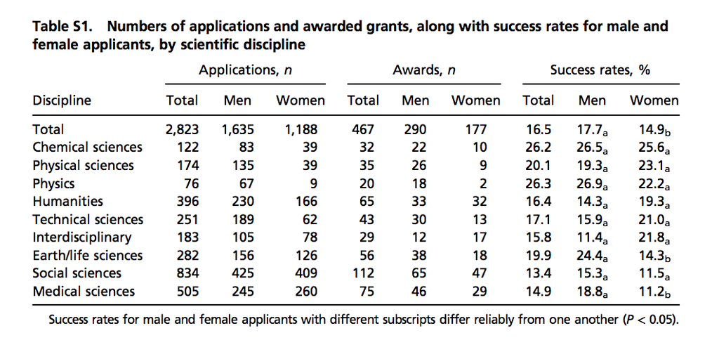

## Example - importing a pdf

The data table was found in a supplemental file provided by the authors

```r
library("pdftools")
temp_file <- tempfile()
url <- paste0("http://www.pnas.org/content/suppl/2015/09/16/",
              "1510159112.DCSupplemental/pnas.201510159SI.pdf")
download.file(url, temp_file)
txt <- pdf_text(temp_file)
file.remove(temp_file)
## [1] TRUE
```

## Example - the text file

- `pdf_text` produces one long string per page
- lines end with `\n`, so we can exploit that

```r
txt
## [1] "Supporting Information\nvan der Lee and Ellemers 10.1073/pnas.1510159112\nSI Text                                                                        applicants’ chances (i.e., evaluations and success rates) of\nGiven that the gender composition of the review committee might                making it through the preselection phase of the grant review\naffect the chances of female applicants to obtain grant funding, we            procedure.\nexamined the role of the share of female reviewers on the success              Review committee. On average, 8.1 reviewers, 32.6% of which were\nrates and committee evaluations of male and female applicants.                 women, took part in the interview committee and evaluated the\nPreselection advisors. On average, 3.4 reviewers rated the appli-              applications on the three assessment criteria. A simple regression\ncations in the preselection phase; 34.9% of the preselection                   analysis showed that the percentage of female reviewers was not\nadvisors were women. A simple regression analysis demonstrated                 associated with the committee evaluations for applicants [β =\nthat the percentage of female preselection advisors was not as-                −0.005, R2 = 0.00, F(1, 1,448) = 0.04, P = 0.85]. Fig. S1 shows the\nsociated with the average preselection advice for applicants [β =              relationship between the percentage of female reviewers and\n−0.03, R2 = 0.03, F(1, 2387) = 1.97, P = 0.16]. In addition, a                 committee evaluations of applicants. A binary logistic regression\nbinary logistic regression analysis showed that the main effect of             analysis also showed that the percentage of female reviewers was\nthe percentage of female preselection advisors on the success                  not associated with applicants’ success rate [B = 0.000, SE =\nrates of applicants in the preselection phase was nonsignificant               0.005, Wald (df = 1) = 0.003, P = 0.96; OR = 1.00, model χ2 (1) =\n[B = 0.001, SE = 0.001, Wald (df = 1) = 0.88, P = 0.35; OR =                   0.003, P = 0.96]. Thus, the representation of female reviewers\n1.00, model χ2 (1) = 0.87, P = 0.35]. In sum, the gender com-                  appeared to be unrelated to the evaluation and success rates of\nposition of the preselection advisors was not associated with                  male and female applicants.\n                 Fig. S1. Scatterplot with the average committee evaluations of applicants as a function of the share of female reviewers.\nvan der Lee and Ellemers www.pnas.org/cgi/content/short/1510159112                                                                           1 of 2\n"
## [2] "                        Table S1. Numbers of applications and awarded grants, along with success rates for male and\n                        female applicants, by scientific discipline\n                                                      Applications, n                    Awards, n                      Success rates, %\n                        Discipline              Total     Men      Women         Total    Men       Women          Total    Men      Women\n                       Total                    2,823    1,635      1,188         467      290         177          16.5    17.7a      14.9b\n                        Chemical sciences         122       83          39         32       22           10         26.2    26.5a      25.6a\n                        Physical sciences         174      135          39         35       26            9         20.1    19.3a      23.1a\n                        Physics                    76       67           9         20       18            2         26.3    26.9a      22.2a\n                        Humanities                396      230         166         65       33           32         16.4    14.3a      19.3a\n                        Technical sciences        251      189          62         43       30           13         17.1    15.9a      21.0a\n                        Interdisciplinary         183      105          78         29       12           17         15.8    11.4a      21.8a\n                        Earth/life sciences       282      156         126         56       38           18         19.9    24.4a      14.3b\n                        Social sciences           834      425         409        112       65           47         13.4    15.3a      11.5a\n                        Medical sciences          505      245         260         75       46           29         14.9    18.8a      11.2b\n                           Success rates for male and female applicants with different subscripts differ reliably from one another (P < 0.05).\n                        Table S2. Numbers of applications and awarded grants, along with success rates for male and\n                        female applicants, by first-time applications vs. reapplications in one call, 2012\n                                                         Applications, n                  Awards, n                     Success rates, %\n                        Category                    Total    Men     Women         Total   Men       Women         Total     Men     Women\n                       Total                         921     527        394         147      93          54         16.0    17.6i      13.7i\n                        First-time applications      722     417        305         100      67          33         13.9i   16.1a      10.8b\n                        Reapplications               199     110         89          47      26          21         23.6j   23.6ac     23.6c\n                           Success rates for male and female applicants with different subscripts per row and column differ reliably from\n                        one another (P < 0.05).\nvan der Lee and Ellemers www.pnas.org/cgi/content/short/1510159112                                                                             2 of 2\n"
raw_data_research_funding_rates <- txt[2]
```

## Example - splitting

```r
tab <- str_split(raw_data_research_funding_rates, "\n")
tab
## [[1]]
##  [1] "                        Table S1. Numbers of applications and awarded grants, along with success rates for male and"
##  [2] "                        female applicants, by scientific discipline"
##  [3] "                                                      Applications, n                    Awards, n                      Success rates, %"
##  [4] "                        Discipline              Total     Men      Women         Total    Men       Women          Total    Men      Women"
##  [5] "                       Total                    2,823    1,635      1,188         467      290         177          16.5    17.7a      14.9b"
##  [6] "                        Chemical sciences         122       83          39         32       22           10         26.2    26.5a      25.6a"
##  [7] "                        Physical sciences         174      135          39         35       26            9         20.1    19.3a      23.1a"
##  [8] "                        Physics                    76       67           9         20       18            2         26.3    26.9a      22.2a"
##  [9] "                        Humanities                396      230         166         65       33           32         16.4    14.3a      19.3a"
## [10] "                        Technical sciences        251      189          62         43       30           13         17.1    15.9a      21.0a"
## [11] "                        Interdisciplinary         183      105          78         29       12           17         15.8    11.4a      21.8a"
## [12] "                        Earth/life sciences       282      156         126         56       38           18         19.9    24.4a      14.3b"
## [13] "                        Social sciences           834      425         409        112       65           47         13.4    15.3a      11.5a"
## [14] "                        Medical sciences          505      245         260         75       46           29         14.9    18.8a      11.2b"
## [15] "                           Success rates for male and female applicants with different subscripts differ reliably from one another (P < 0.05)."
## [16] "                        Table S2. Numbers of applications and awarded grants, along with success rates for male and"
## [17] "                        female applicants, by first-time applications vs. reapplications in one call, 2012"
## [18] "                                                         Applications, n                  Awards, n                     Success rates, %"
## [19] "                        Category                    Total    Men     Women         Total   Men       Women         Total     Men     Women"
## [20] "                       Total                         921     527        394         147      93          54         16.0    17.6i      13.7i"
## [21] "                        First-time applications      722     417        305         100      67          33         13.9i   16.1a      10.8b"
## [22] "                        Reapplications               199     110         89          47      26          21         23.6j   23.6ac     23.6c"
## [23] "                           Success rates for male and female applicants with different subscripts per row and column differ reliably from"
## [24] "                        one another (P < 0.05)."
## [25] "van der Lee and Ellemers www.pnas.org/cgi/content/short/1510159112                                                                             2 of 2"
## [26] ""

tab <- tab[[1]]
```

## Example - column names

Column names are in the third and fourth entries

```r
tab
##  [1] "                        Table S1. Numbers of applications and awarded grants, along with success rates for male and"
##  [2] "                        female applicants, by scientific discipline"
##  [3] "                                                      Applications, n                    Awards, n                      Success rates, %"
##  [4] "                        Discipline              Total     Men      Women         Total    Men       Women          Total    Men      Women"
##  [5] "                       Total                    2,823    1,635      1,188         467      290         177          16.5    17.7a      14.9b"
##  [6] "                        Chemical sciences         122       83          39         32       22           10         26.2    26.5a      25.6a"
##  [7] "                        Physical sciences         174      135          39         35       26            9         20.1    19.3a      23.1a"
##  [8] "                        Physics                    76       67           9         20       18            2         26.3    26.9a      22.2a"
##  [9] "                        Humanities                396      230         166         65       33           32         16.4    14.3a      19.3a"
## [10] "                        Technical sciences        251      189          62         43       30           13         17.1    15.9a      21.0a"
## [11] "                        Interdisciplinary         183      105          78         29       12           17         15.8    11.4a      21.8a"
## [12] "                        Earth/life sciences       282      156         126         56       38           18         19.9    24.4a      14.3b"
## [13] "                        Social sciences           834      425         409        112       65           47         13.4    15.3a      11.5a"
## [14] "                        Medical sciences          505      245         260         75       46           29         14.9    18.8a      11.2b"
## [15] "                           Success rates for male and female applicants with different subscripts differ reliably from one another (P < 0.05)."
## [16] "                        Table S2. Numbers of applications and awarded grants, along with success rates for male and"
## [17] "                        female applicants, by first-time applications vs. reapplications in one call, 2012"
## [18] "                                                         Applications, n                  Awards, n                     Success rates, %"
## [19] "                        Category                    Total    Men     Women         Total   Men       Women         Total     Men     Women"
## [20] "                       Total                         921     527        394         147      93          54         16.0    17.6i      13.7i"
## [21] "                        First-time applications      722     417        305         100      67          33         13.9i   16.1a      10.8b"
## [22] "                        Reapplications               199     110         89          47      26          21         23.6j   23.6ac     23.6c"
## [23] "                           Success rates for male and female applicants with different subscripts per row and column differ reliably from"
## [24] "                        one another (P < 0.05)."
## [25] "van der Lee and Ellemers www.pnas.org/cgi/content/short/1510159112                                                                             2 of 2"
## [26] ""
```

## Example - column names

```r
the_names_1 <- tab[3]
the_names_2 <- tab[4]
```

## Example - the_names_1

```
##                                                       Applications, n
##                Awards, n                      Success rates, %
```

We need to get these into one vector

- remove leading space
- remove anything following the comma
- split string by 2+ spaces

## Example - the_names_1

```r
the_names_1 <- the_names_1 %>%
  str_trim() %>%
  str_replace_all(",\\s.", "") %>%
  str_split("\\s{2,}", simplify = TRUE)
the_names_1
##      [,1]           [,2]     [,3]
## [1,] "Applications" "Awards" "Success rates"
```

## Example - the_names_2

```
##                         Discipline              Total     Men      Women
##        Total    Men       Women          Total    Men      Women
```

- trim leading spaces
- split by spaces

## Example - the_names_2

```r
the_names_2 <- the_names_2 %>%
  str_trim() %>%
  str_split("\\s+", simplify = TRUE)
the_names_2
##      [,1]         [,2]    [,3]  [,4]    [,5]    [,6]  [,7]    [,8]
## [1,] "Discipline" "Total" "Men" "Women" "Total" "Men" "Women" "Total"
##      [,9]  [,10]
## [1,] "Men" "Women"
```

## Example - join names

```r
tmp_names <- str_c(rep(the_names_1, each = 3), the_names_2[-1], sep = "_")
the_names <- c(the_names_2[1], tmp_names) %>%
  str_to_lower() %>%
  str_replace_all("\\s", "_")
the_names
##  [1] "discipline"          "applications_total"  "applications_men"
##  [4] "applications_women"  "awards_total"        "awards_men"
##  [7] "awards_women"        "success_rates_total" "success_rates_men"
## [10] "success_rates_women"
```

## Example - the data

```r
tab
##  [1] "                        Table S1. Numbers of applications and awarded grants, along with success rates for male and"
##  [2] "                        female applicants, by scientific discipline"
##  [3] "                                                      Applications, n                    Awards, n                      Success rates, %"
##  [4] "                        Discipline              Total     Men      Women         Total    Men       Women          Total    Men      Women"
##  [5] "                       Total                    2,823    1,635      1,188         467      290         177          16.5    17.7a      14.9b"
##  [6] "                        Chemical sciences         122       83          39         32       22           10         26.2    26.5a      25.6a"
##  [7] "                        Physical sciences         174      135          39         35       26            9         20.1    19.3a      23.1a"
##  [8] "                        Physics                    76       67           9         20       18            2         26.3    26.9a      22.2a"
##  [9] "                        Humanities                396      230         166         65       33           32         16.4    14.3a      19.3a"
## [10] "                        Technical sciences        251      189          62         43       30           13         17.1    15.9a      21.0a"
## [11] "                        Interdisciplinary         183      105          78         29       12           17         15.8    11.4a      21.8a"
## [12] "                        Earth/life sciences       282      156         126         56       38           18         19.9    24.4a      14.3b"
## [13] "                        Social sciences           834      425         409        112       65           47         13.4    15.3a      11.5a"
## [14] "                        Medical sciences          505      245         260         75       46           29         14.9    18.8a      11.2b"
## [15] "                           Success rates for male and female applicants with different subscripts differ reliably from one another (P < 0.05)."
## [16] "                        Table S2. Numbers of applications and awarded grants, along with success rates for male and"
## [17] "                        female applicants, by first-time applications vs. reapplications in one call, 2012"
## [18] "                                                         Applications, n                  Awards, n                     Success rates, %"
## [19] "                        Category                    Total    Men     Women         Total   Men       Women         Total     Men     Women"
## [20] "                       Total                         921     527        394         147      93          54         16.0    17.6i      13.7i"
## [21] "                        First-time applications      722     417        305         100      67          33         13.9i   16.1a      10.8b"
## [22] "                        Reapplications               199     110         89          47      26          21         23.6j   23.6ac     23.6c"
## [23] "                           Success rates for male and female applicants with different subscripts per row and column differ reliably from"
## [24] "                        one another (P < 0.05)."
## [25] "van der Lee and Ellemers www.pnas.org/cgi/content/short/1510159112                                                                             2 of 2"
## [26] ""
```

## Example - the data

```r
new_research_funding_rates <- tab[6:14] %>%
  str_trim %>%
  str_split("\\s{2,}", simplify = TRUE) %>%
  data.frame(stringsAsFactors = FALSE) %>%
  setNames(the_names) %>%
  mutate_at(-1, parse_number)
new_research_funding_rates %>% as_tibble()
## # A tibble: 9 x 10
##   discipline applications_to… applications_men applications_wo…
##   <chr>                 <dbl>            <dbl>            <dbl>
## 1 Chemical …              122               83               39
## 2 Physical …              174              135               39
## 3 Physics                  76               67                9
## 4 Humanities              396              230              166
## 5 Technical…              251              189               62
## 6 Interdisc…              183              105               78
## 7 Earth/lif…              282              156              126
## 8 Social sc…              834              425              409
## 9 Medical s…              505              245              260
## # … with 6 more variables: awards_total <dbl>, awards_men <dbl>,
## #   awards_women <dbl>, success_rates_total <dbl>,
## #   success_rates_men <dbl>, success_rates_women <dbl>
```

## Example - the data

```r
new_research_funding_rates %>%
  select(discipline, starts_with("success_rates")) %>%
  as_tibble()
## # A tibble: 9 x 4
##   discipline        success_rates_total success_rates_m… success_rates_wom…
##   <chr>                           <dbl>            <dbl>              <dbl>
## 1 Chemical sciences                26.2             26.5               25.6
## 2 Physical sciences                20.1             19.3               23.1
## 3 Physics                          26.3             26.9               22.2
## 4 Humanities                       16.4             14.3               19.3
## 5 Technical scienc…                17.1             15.9               21
## 6 Interdisciplinary                15.8             11.4               21.8
## 7 Earth/life scien…                19.9             24.4               14.3
## 8 Social sciences                  13.4             15.3               11.5
## 9 Medical sciences                 14.9             18.8               11.2
```

## Example - the data

```r
new_research_funding_rates %>%
  select(discipline, starts_with("success_rates")) %>%
  rename_all(funs(stringr::str_replace_all(., "success_rates_", ""))) %>%
  mutate(difference = women - men) %>%
  as_tibble()
## # A tibble: 9 x 5
##   discipline          total   men women difference
##   <chr>               <dbl> <dbl> <dbl>      <dbl>
## 1 Chemical sciences    26.2  26.5  25.6     -0.900
## 2 Physical sciences    20.1  19.3  23.1      3.8
## 3 Physics              26.3  26.9  22.2     -4.70
## 4 Humanities           16.4  14.3  19.3      5
## 5 Technical sciences   17.1  15.9  21        5.1
## 6 Interdisciplinary    15.8  11.4  21.8     10.4
## 7 Earth/life sciences  19.9  24.4  14.3    -10.1
## 8 Social sciences      13.4  15.3  11.5     -3.8
## 9 Medical sciences     14.9  18.8  11.2     -7.6
```

## Example - plot

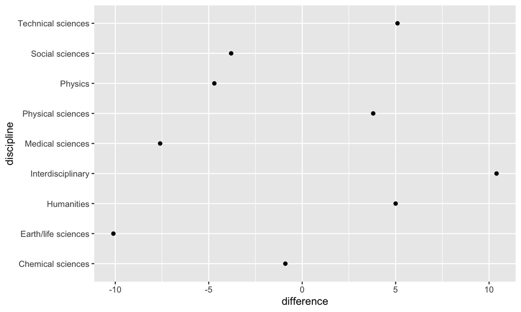

```r
new_research_funding_rates %>%
  select(discipline, starts_with("success_rates")) %>%
  rename_all(funs(stringr::str_replace_all(., "success_rates_", ""))) %>%
  mutate(difference = women - men) %>%
  qplot(difference, discipline, data=.)
```

## Reason for factors

```r
x1 <- c("Dec", "Apr", "Jan", "Mar")
x2 <- c("Dec", "Apr", "Jam", "Mar")
sort(x1)
## [1] "Apr" "Dec" "Jan" "Mar"
```

## Factor levels

```r
month_levels <- c(
  "Jan", "Feb", "Mar", "Apr", "May", "Jun",
  "Jul", "Aug", "Sep", "Oct", "Nov", "Dec"
)
y1 <- factor(x1, levels = month_levels)
sort(y1)
## [1] Jan Mar Apr Dec
## Levels: Jan Feb Mar Apr May Jun Jul Aug Sep Oct Nov Dec
```

## Factor levels

```r
y2 <- factor(x2, levels = month_levels)
y2
## [1] Dec  Apr  <NA> Mar
## Levels: Jan Feb Mar Apr May Jun Jul Aug Sep Oct Nov Dec
y2 <- parse_factor(x2, levels = month_levels)
```

## Reordering factors

```r
funding_rates <- new_research_funding_rates %>%
  mutate(discipline = factor(discipline)) %>%
  select(discipline, starts_with("success_rates")) %>%
  rename_all(funs(stringr::str_replace_all(., "success_rates_", ""))) %>%
  mutate(difference = women - men)
```

```r
funding_rates$discipline <- fct_reorder(.f = funding_rates$discipline, .x = funding_rates$difference)
funding_rates$discipline
## [1] Chemical sciences   Physical sciences   Physics
## [4] Humanities          Technical sciences  Interdisciplinary
## [7] Earth/life sciences Social sciences     Medical sciences
## 9 Levels: Earth/life sciences Medical sciences ... Interdisciplinary
```

## Better plot

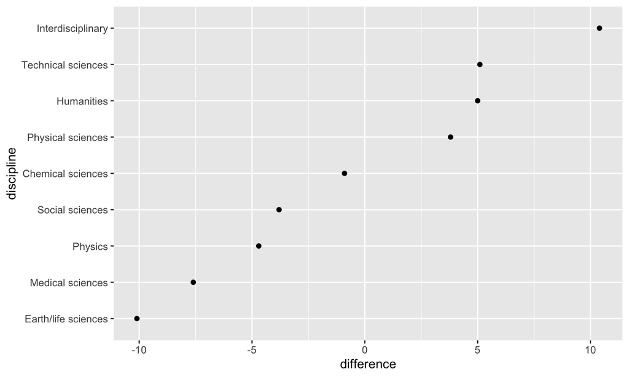

## More options

See R4DS Chapter 15 for more options, like:

- `fct_reorder2`: reorder based on two variables
- `fct_relevel`: move factor level(s) to “the front of the line”
- `fct_infreq`: order levels by frequency
- `fct_recode`: recode factor levels (see also `fct_collapse`)
- `fct_lump`: lump together infrequent factor levels